# CSSS 508, Week 10: Social Media and Text Mining

Charles Lanfear  
May 31st, 2017

### Topics

- Collecting Twitter data with `twitteR`, `streamR`, and `SocialMediaLab`
- Mining text with `tm`
- Wrapping up the course

## Collecting Twitter Data

### Some Terminology

- Application Program Interface (API): A type of computer interface that exists as the “native” method of communication between computers, often via http (usable via `httr` package).
  - R packages that interface with websites and databases typically use APIs.
- XML and JSON: File formats commonly used for commucation via APIs.
  - Can be parsed with the `jsonlite` and `XML` packages.
- Scrape: The act of extracting data from sources designed to be human readable rather than machine readable.
  - Technically if one goes through an API, it is not *scraping* data.
  - R can be used to scrape from sources without an API but technical knowledge is required.
- Rate Limit: A web service's limit to the number of pieces of data you can download in a given period of time (use `Sys.sleep()` to deal with this).

### Twitter

Twitter has two APIs for obtaining data from tweets and users:

- Twitter REST API
  - Allows reading and writing Twitter data.
  - Can obtain tweets from specific dates and places easily, but doesn't get *everything*
  - Good for obtaining lots of data, data over time, etc.
- Twitter Streaming API:
  - Obtains tweets as they are being posted.
  - Only gives you tweets that were posted while you are watching.
  - Good for following trends, live events, etc.

### Set Up

```r
library(SocialMediaLab); library(tidyverse); library(stringr); library(twitteR); library(ROAuth); library(grid); library(streamR)

api_key <- "API KEY GOES HERE"
api_secret <- "API SECRET GOES HERE"
access_token <- "ACCESS TOKEN GOES HERE"
access_token_secret <- "ACCESS TOKEN SECRET GOES HERE"

reqURL <- "https://api.twitter.com/oauth/request_token"
accessURL<- "https://api.twitter.com/oauth/access_token"
authURL<- "https://api.twitter.com/oauth/authorize"
```

## Social Media Lab

### Social Media Lab

Social Media Lab provides a “one-stop shop” for accessing social media data and transforming it for network analysis techniques. It works with:

- Twitter (Tweets from REST API)
- Facebook (Pages and public posts)
- Instagram (Public pictures and comments)
- YouTube (Videos and comments)

Data from all of these can be collected and analyzed using the same syntax! [See this introduction to see exactly how much it can do](http://www.academia.edu/19064267/Absolute_Beginners_Guide_to_the_SocialMediaLab_package_in_R).

### SML Work Flow

Social Media Lab has a simple workflow for collecting data:

1. `Authenticate()` using your credentials
2. Pipe authentication to…
3. `Collect()` where you can specify search parameters.
4. Then either…
   - Use the data as they are for text analysis
   - Use `Create` to generate network data

It will perform the search and process the data into a usable data frame. This beats handling `JSON` files yourself!

### Twitter's REST API

```r
tweets_Trump <- Authenticate("twitter", api_key, api_secret, access_token, access_token_secret) %>% Collect(searchTerm="Trump", language="en", verbose=TRUE) %>% as_tibble()

tweets_Trump %>% arrange(retweetCount) %>% select(text)
```

```
# A tibble: 1,500 × 1
                                                                            text
                                                                           <chr>
1    Come and see Trump News and see what the orange menace has been up to - htt
2    Having exhausted every other line of attack, New Republic writer goes after
3  Please tell Mocha to log out of Trump's account.\n\nCovfefe and Maram = Symbo
4    Trump believes the trip was a home run where ever he went. He's delusional
5    The Loneliness of Donald Trump. Great read - take time to savour this brill
6  What is covfefe? Donald Trump baffles with late night Twitter post\n\nhttps:/
7    @Hirazistable If we get married Trump won't let me make the decision to pul
8    @Mikel_Jollett Exactly! Trump is a disaster for the country and the world.
9    I like thinking big. If youÃ¢â¬â¢re going to be thinking anything, you mi
10   Trump: "How much covfefing does a guy gotta do to get some service around h
# ... with 1,490 more rows
```

### Twitter's REST API 2

```r
tweets_UW <- Authenticate("twitter", api_key, api_secret,
                                access_token, access_token_secret) %>%
  Collect(geocode="47.6552083,-122.30833,2mi", searchTerm=" ",
          language="en", verbose=TRUE)

tweets_UW %>% arrange(retweetCount) %>% select(text)
```

```
                                                                                                                                                                                                                                                                                         text
1                                                                                                                                                             For the Cafe Racer family: The Day The Circus Left Town, a work of love by Hugh Sutton - https://t.co/qEv1HMORKF #caferacerlove
2                                                                                                                                                                                                                     Air Jordan 3 "5Lab3" Black $275 #5lab3 @ Recess https://t.co/fdo0baUoUy
3                                                                                                                                                                                                           Air Jordan 4 "Thunder" $185 #thunder4 #thunder4s @ Recess https://t.co/HJuXnCGDTP
4                                                                                                                                                                                                           Air Jordan 4 "Thunder" $185 #thunder4s #thunder4 @ Recess https://t.co/nzI4nfEZ2R
5                                                                                                                                                                                                                   I just miss it already ÃÂ Â½ÃÂ¸Â @iamblackbear https://t.co/MPS3Cyu1mO
6                                                                                                                                                               Meal 5 and 6. #mejarifusionsushi #seattle #wallingford #sushi #sashimi #foodisfuel #musclefoodÃ¢â¬Â¦ https://t.co/HM2GmavsF1
7                                                                                                                                                                                           Kalmia latifolia ... These are some funky flowers! The anthers popÃ¢â¬Â¦ https://t.co/uudIquuHCF
8                                                                                                                                                                                                                                                   @kibblenbits I saw this on Vox. Terrific!
9                                                                                                                                                                                                                           Regexes were put on this earth to test me, IÃ¢â¬â¢m sure of it.
10                                                                                                                                                                                                                    I want the Sadies to adopt us @ Neptune Theatre https://t.co/8oTnAS9iPe
11                                                                                                                                                                                                                    Udistrict sunset @ Flowers Bar &amp; Restaurant https://t.co/l7HRvKJYlG
12                                                                                                                                                                                                 Justin Townes Earle Sighting: Seattle, Washington/ Neptune Theatre https://t.co/CdPFH5zttS
13                                                                                                                                                                                    Last day of grad school!!! WOOF!!! #nerd #mba #dawgs @ University of Washington https://t.co/Ff8KrvD8Pp
14                                                                                                                                                                                       Today was a good one !!! Renting a house and starting a sticker business !!! https://t.co/4DotCQTmTF
```

[output cut: 1025 more lines]

### Twitter Stream with streamR

There are a few packages that can access the Twitter Stream API including `streamR`. Since the Stream API is less commonly used in Social Science, the packages are a bit “rough around the edges” and require more finicky setup.

### streamR Setup

```r
download.file(url="http://curl.haxx.se/ca/cacert.pem", destfile="cacert.pem")
twitCred<- OAuthFactory$new(consumerKey=api_key,
                            consumerSecret=api_secret,
                            requestURL=reqURL,
                            accessURL=accessURL,
                            authURL=authURL)

# insert the number in the R console after you run this
twitCred$handshake(cainfo = system.file("CurlSSL", "cacert.pem", package = "RCurl"))

# Then save this so you don't need to do it again
save(twitCred, file = "twitCred.Rdata")
```

### streamR

`sampleStream()` downloads streaming tweets of no particular topic.

```r
tweets_stream <- sampleStream("", timeout=10, oauth=twitCred)
```

`filterStream()` downloads streaming tweets based on search parameters.

```r
tweets_Trump  <- filterStream("", track="Trump", timeout=10, oauth=twitCred)
```

### streamR

Once you've streamed data in you need to parse it from JSON format into a data frame for it to be particularly useful.

```r
tweets_from_stream <- parseTweets(tweets_stream, verbose = FALSE)
as_tibble(tweets_from_stream) %>% arrange(followers_count) %>% select(name)
```

```
# A tibble: 240 × 1
                                                                                                                                                               name
                                                                                                                                                              <chr>
1                                                                                                                                                      Helen Howell
2                                                                                                                                                 Chococaromishanos
3  素敵なイラスト描き様を世界に広めましょう
4                                                                                                                                                       Jutino Ñato
5                                                                                                                                                   Pepe Concepción
6                                                                                                                                                    DíaJaramishano
7                                                                                                                                                 ChocoJaramishanos
8                                                                                                                                                         masayoshi
9                                                                                                                                                   JaramishanosMMD
10                                                                                                                                                        Black cat
# ... with 230 more rows
```

### Using streamR

Since it collects tweets in real time, the streaming API tends to be most useful when you leave it running *for a long time*.

You can use it to monitor events as they're happening, or to catch a “snapshot” in time.

I let it run for 1200 seconds to replicate an example by the package author, Pablo Barbera, in which tweets in the US are collected and then mapped in ggplot.

### Using streamR

```r
filterStream("tweetsUS.json", locations = c(-125, 25, -66, 50), timeout = 1200,
             oauth = twitCred)
tweets.df <- parseTweets("tweetsUS.json", verbose = FALSE)
map.data <- map_data("state")
points <- data.frame(x = as.numeric(tweets.df$lon), y = as.numeric(tweets.df$lat))
points <- points[points$y > 25, ]
ggplot(map.data) + geom_map(aes(map_id = region), map = map.data, fill = "white",
                            color = "grey20", size = 0.25) + expand_limits(x = map.data$long, y = map.data$lat) +
  theme(axis.line = element_blank(), axis.text = element_blank(), axis.ticks = element_blank(),
        axis.title = element_blank(), panel.background = element_blank(), panel.border = element_blank(),
        panel.grid.major = element_blank(), plot.background = element_blank(),
        plot.margin = unit(0 * c(-1.5, -1.5, -1.5, -1.5), "lines")) +
  geom_point(data = points, aes(x = x, y = y), size = 1, alpha = 1/5, color = "darkblue")
```

### Using streamR

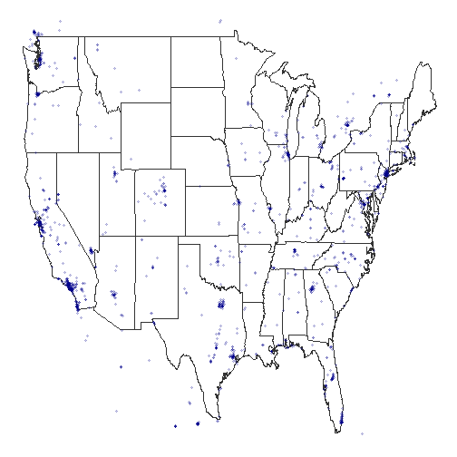

### Using Twitter Data

Remember, Twitter data can be challenging to make sense of, so it is most useful when approached using text analysis techniques.

But even they might not help:

[figure not shown]

## Text Mining with tm

### Text Mining Terminology

- `tm`: R package for performing text mining
- **Term**: A word
- **Document**: A collection of *terms*
- **Corpus**: A collection of *documents* (plural: corpora)
- **Dictionary**: A set of relevant *terms*

### My First Corpus

We can make a basic corpus manually by creating a character vector, running `VectorSource()` on it to read it in, and then `VCorpus()` to corpus-ify:

```r
library(tm)
UW_tweets <- c("Remembering and honoring those who made the ultimate sacrifice while serving our country. #MemorialDay2016", "VIDEO: This spring @UW students taught literacy arts to #Colville Reservation students. Check out book they made!", "Enjoy the long weekend, Huskies! And to those studying for finals: Good luck and hang in there!", ".@UWBuerk & @UWFosterSchool–hosted biz plan competition awards $85,000 to students for new ventures. http://ow.ly/3PtI300F87Y  #UWinnovates")
toy_corpus <- VCorpus(VectorSource(UW_tweets))
```

### Accessing Corpus Entries

A corpus is just a fancy list of documents, and you can access a document as a list entry:

```r
toy_corpus[[3]]
```

```
<<PlainTextDocument>>
Metadata:  7
Content:  chars: 95
```

```r
as.character(toy_corpus[[3]])
```

```
[1] "Enjoy the long weekend, Huskies! And to those studying for finals: Good luck and hang in there!"
```

### Text Files as Documents

You will more likely be making corpora from sources like Twitter or reading in data from text files.

We'll import a sample of emails from the [Enron corpus](http://bailando.sims.berkeley.edu/enron_email.html) assembled by UC Berkeley students. First, let's download a ZIP file with the text files and unzip it.

```r
download.file("http://clanfear.github.io/CSSS508/Lectures/Week10/enron_sample_emails.zip", destfile = "enron_emails.zip", mode = "wb")
unzip("enron_emails.zip", exdir = "enron_emails")
```

```r
length(list.files("enron_emails/enron_sample_emails"))
```

```
[1] 100
```

### Reading in Text Files

Make a corpus where each document is an email in the Enron subsample:

```r
enron_corpus <- VCorpus(DirSource(directory = "enron_emails/enron_sample_emails", mode = "text"))
as.character(enron_corpus[[3]])
```

```
 [1] "Message-ID: <26658543.1075843310470.JavaMail.evans@thyme>"
 [2] "Date: Fri, 22 Dec 2000 04:00:00 -0800 (PST)"
 [3] "From: sarah.novosel@enron.com"
 [4] "To: susan.mara@enron.com"
 [5] "Subject: Re: Wolak report"
 [6] "Cc: donna.fulton@enron.com, jeff.dasovich@enron.com"
 [7] "Mime-Version: 1.0"
 [8] "Content-Type: text/plain; charset=us-ascii"
 [9] "Content-Transfer-Encoding: 7bit"
[10] "Bcc: donna.fulton@enron.com, jeff.dasovich@enron.com"
[11] "X-From: Sarah Novosel"
[12] "X-To: Susan J Mara"
[13] "X-cc: Donna Fulton, Jeff Dasovich"
[14] "X-bcc: "
[15] "X-Folder: \\Jeff_Dasovich_June2001\\Notes Folders\\All documents"
```

[output cut: 29 more lines]

### Transformations (maps)

Let's change to lowercase, remove “stopwords” and header terms, remove punctuation, numbers, and whitespace, and “stem” the words:

```r
# install.packages("SnowballC") # may solve errors
enron_stripped <- enron_corpus %>%
    tm_map(content_transformer(str_to_lower)) %>%
    tm_map(removeWords, stopwords("english")) %>%
    tm_map(removeWords, c("javamail.evans@thyme", "message-id", "date", "subject", "mime-version", "content-type", "text/plain", "charset=us-ascii", "content-transfer-encoding", "x-", "x-cc", "x-bcc", "x-folder", "x-origin", "x-filename")) %>%
    tm_map(removePunctuation) %>%
    tm_map(removeNumbers) %>%
    tm_map(stripWhitespace) %>%
    tm_map(stemDocument)
```

### Word clouds

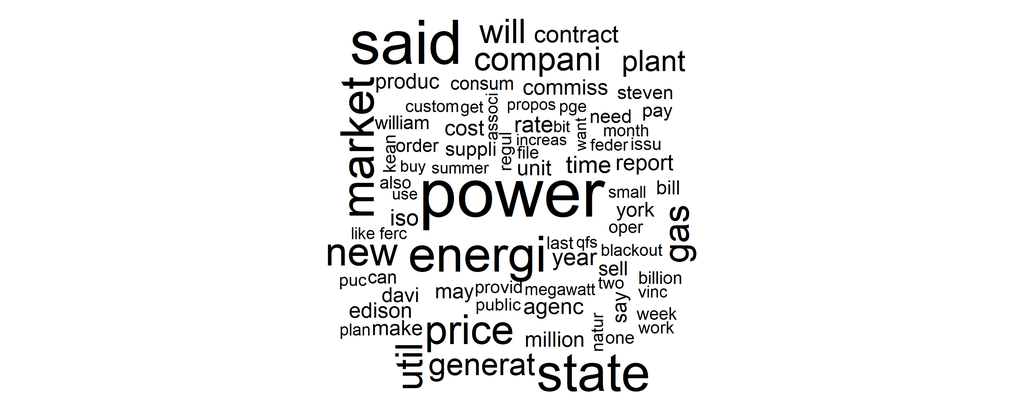

```r
library(wordcloud); library(RColorBrewer)
wordcloud(enron_stripped, min.freq = 2, max.words = 80)
```

### Filtering to Emails with California

We'll write a function that takes the content of the documents and looks for any instance of `"california"`, then use it with `tm_filter()`:

```r
doc_word_search <- function(x, pattern) {
    any(str_detect(content(x), pattern = pattern))
}
cali_emails <- enron_stripped %>%
    tm_filter(doc_word_search, pattern = "california")
length(cali_emails)
```

```
[1] 14
```

### Term-Document Matrices

We can look for patterns across the documents by constructing a `TermDocumentMatrix()`:

```r
enron_tdm <- TermDocumentMatrix(enron_stripped)
str(enron_tdm)
```

```
List of 6
 $ i       : int [1:17721] 2 9 12 15 17 19 24 27 30 34 ...
 $ j       : int [1:17721] 1 1 1 1 1 1 1 1 1 1 ...
 $ v       : num [1:17721] 4 1 1 1 1 2 1 1 2 4 ...
 $ nrow    : int 5061
 $ ncol    : int 100
 $ dimnames:List of 2
  ..$ Terms: chr [1:5061] "abat" "abil" "abl" "abnorm" ...
  ..$ Docs : chr [1:100] "114495.txt" "115323.txt" "118675.txt" "119214.txt" ...
 - attr(*, "class")= chr [1:2] "TermDocumentMatrix" "simple_triplet_matrix"
 - attr(*, "weighting")= chr [1:2] "term frequency" "tf"
```

### What Does the Matrix Look Like?

Too big to view at once, but we can look at snippets with `inspect()`:

```r
inspect(enron_tdm[1:5, 1:5])
```

```
<<TermDocumentMatrix (terms: 5, documents: 5)>>
Non-/sparse entries: 2/23
Sparsity           : 92%
Maximal term length: 7
Weighting          : term frequency (tf)
Sample             :
         Docs
Terms     114495.txt 115323.txt 118675.txt 119214.txt 12030.txt
  abat             0          0          0          0         0
  abil             4          0          0          0         0
  abl              0          0          0          0         1
  abnorm           0          0          0          0         0
  abolish          0          0          0          0         0
```

### Removing Sparse Words

We could focus on words that appear in at least 40% of documents.

```r
enron_tdm_sparse <- removeSparseTerms(enron_tdm, 0.60)
inspect(enron_tdm_sparse)
```

```
<<TermDocumentMatrix (terms: 11, documents: 100)>>
Non-/sparse entries: 659/441
Sparsity           : 40%
Maximal term length: 18
Weighting          : term frequency (tf)
Sample             :
                    Docs
Terms                114495.txt 173842.txt 174212.txt 174517.txt
  bit                         1          1          0          1
  document                    2          1          1          1
  folder                      1          1          1          1
  forward                     3          1          1          5
  kean                        0          2          2          2
  pdt                         1          1          1          1
  steven                      0          3          2          3
  stevenkeanenroncom          0          1          1          1
  thank                       2          1          0          1
  will                       19          4          8          6
                    Docs
Terms                175607.txt 175617.txt 176601.txt 176805.txt
  bit                         1          1          1          1
  document                    3          1          1          2
  folder                      1          1          1          0
  forward                     8          1          0          8
  kean                        1          2          2          1
  pdt                         0          0          1          0
  steven                      0          3          1          0
  stevenkeanenroncom          0          1          1          0
  thank                       1          4          4          1
  will                       73          2          5         73
                    Docs
Terms                177215.txt 255511.txt
  bit                         1          2
  document                    2          2
  folder                      0          1
  forward                     8          3
  kean                        1          0
  pdt                         0          1
  steven                      0          0
  stevenkeanenroncom          0          0
  thank                       1          2
  will                       73         19
```

### Favorite Dictionary Words

Or we can make make a term-document matrix focusing on words in a dictionary and look at just those columns:

```r
inspect(TermDocumentMatrix(enron_stripped, list(dictionary = c("california", "utah", "texas")))[, 1:5])
```

```
<<TermDocumentMatrix (terms: 3, documents: 5)>>
Non-/sparse entries: 2/13
Sparsity           : 87%
Maximal term length: 10
Weighting          : term frequency (tf)
Sample             :
            Docs
Terms        114495.txt 115323.txt 118675.txt 119214.txt 12030.txt
  california          1          1          0          0         0
  texas               0          0          0          0         0
  utah                0          0          0          0         0
```

### Most Frequent Words

Which terms appear at least 200 times?

```r
findFreqTerms(enron_tdm, 200)
```

```
 [1] "california" "compani"    "contract"   "electr"     "energi"
 [6] "gas"        "generat"    "market"     "new"        "plant"
[11] "power"      "price"      "said"       "state"      "time"
[16] "util"       "will"       "year"
```

### Word Associations

Which words co-occur frequently with “california”?

```r
findAssocs(enron_tdm, "california", 0.90)
```

```
$california
                             citizen                               condit
                                1.00                                 1.00
                              consum                               credit
                                1.00                                 1.00
                              dynegi                            economist
                                1.00                                 1.00
                              electr                               energi
                                1.00                                 1.00
                              enough                              essenti
                                1.00                                 1.00
                                forc                               higher
                                1.00                                 1.00
                              includ                              increas
                                1.00                                 1.00
                            investig                                locat
                                1.00                                 1.00
                              market                                order
                                1.00                                 1.00
                               power                                press
                                1.00                                 1.00
                              provid                                regul
                                1.00                                 1.00
                             reliabl                               report
                                1.00                                 1.00
                                roll                           sacramento
                                1.00                                 1.00
                            statewid                                 step
                                1.00                                 1.00
                            structur                               summer
                                1.00                                 1.00
                              suppli                                three
                                1.00                                 1.00
                             weather                                whose
                                1.00                                 1.00
                              abnorm                              abolish
                                0.99                                 0.99
                             abraham                              absolut
                                0.99                                 0.99
                              access                           accomplish
```

[output cut: 1748 more lines]

```
                                0.90                                 0.90
                             expedit                               extens
                                0.90                                 0.90
                                hold                               morgan
                                0.90                                 0.90
                               other                              prevent
                                0.90                                 0.90
                              provis                             reaction
                                0.90                                 0.90
                               reduc                              schedul
                                0.90                                 0.90
                                stay                               street
                                0.90                                 0.90
                               unabl
                                0.90
```

### What Else Might You Do?

- Use the `tidytext` package to work in a “tidy” way
- Make more visualizations of word frequencies or relationships in `ggplot2`
- Use hierarchical clustering to group together terms
- Fit topic models to find overarching topics
- Use `NLP` package to find bigrams (two-word phrases)
- Use `qdap` package to classify document sentiment (positive, negative) and look for relationships

(Please social science responsibly!)

## Wrapping up the Course

### What You've Learned

A lot!

- How to get data into R from a variety of formats
- How to do “data janitor” work to manipulate and clean data
- How to make pretty visualizations
- How to automate with loops and functions
- How to combine text, calculations, plots, and tables into dynamic R Markdown reports

### What Comes Next?

- Statistical inference (e.g. more CSSS courses)
  - Functions for hypothesis testing, hierarchical/mixed effect models, machine learning, survey design, etc. are straightforward to use… once data are clean
  - Access output by working with list structures (like from regression models)
- Practice, practice, practice!
  - Replicate analyses you've done in Excel, SPSS, or Stata
  - Think about data using `dplyr` verbs, tidy data principles
  - R Markdown for documenting cleaning and analysis start-to-finish
- More advanced projects
  - Using version control (git) in RStudio
  - Interactive Shiny web apps

### Course Plugs

If you…

- have no stats background yet - **SOC504: Applied Social Statistics**
- liked today - **SOC590: Big Data and Population Processes**
- have (only) finished SOC506 - **CSSS510: Maximum Likelihood**
- want to master visualization - **CSSS569: Visualizing Data**
- study events or durations - **CSSS544: Event History Analysis**
- want to use network data - **CSSS567: Social Network Analysis**
- want to map - **CSSS554: Spatial Statistics**